# [EM1413] - Health Data Science

## 4.4 Hypertension and Medical Advice

### 4.4.1 Have people diagnosed with hypertension received advice to practice physical activity?

```r
# Filter the responses without including NA values
dataset_contingency = dataset_definitivo %>%
  filter(s07_press_alta %in% c(1, 2),
         s07_sugg_att_fis_press %in% c(1, 2)) %>%
  mutate(
    ipertensione = ifelse(s07_press_alta == 1, "Hypertensive", "No Hypertensive"),
    consiglio_att_fisica = ifelse(s07_sugg_att_fis_press == 1, "Advice Received", "No Advice")
  )

# Absolute frequency table
contingency_table = table(dataset_contingency$ipertensione, dataset_contingency$consiglio_att_fisica)
print(contingency_table)
```

```
##
##                Advice Received No Advice
##   Hypertensive            1989       436
```

```r
# Percentages per raw
percentage_table <- prop.table(contingency_table, margin = 1) * 100
print(round(percentage_table, 1))
```

```
##
##                Advice Received No Advice
##   Hypertensive              82        18
```

Contingency table show that among individuals who were told they have high blood pressure (hypertensive):  
• **1989** received advice to do physical activity (82%);  
• **436** did not receive such advice (18%).

### 4.4.2 Hypertension distribution by Age and Gender

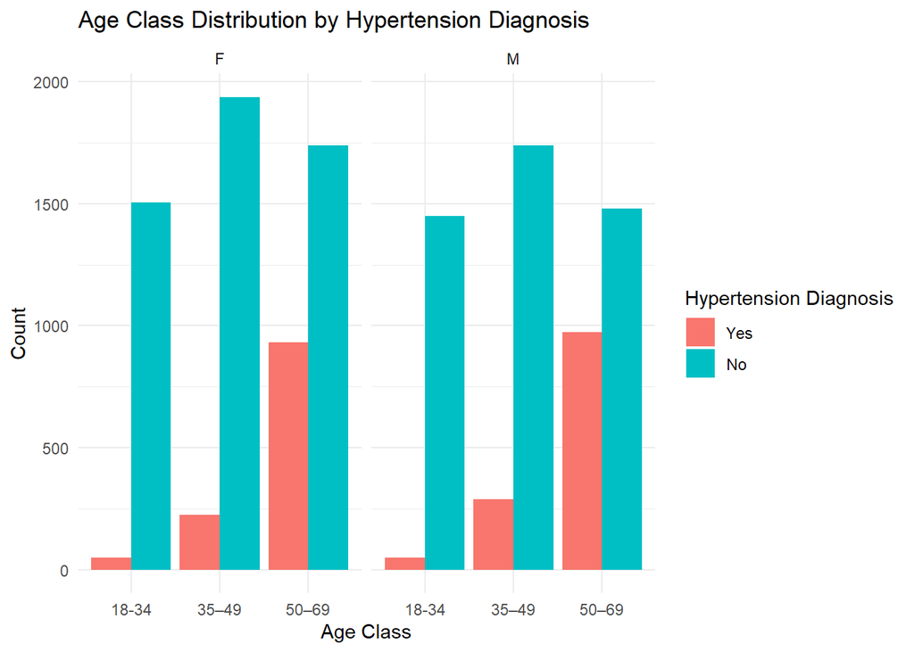

```r
# Histogram of Age Distribution Based on Hypertension Diagnosis

# Creating a dataset of hypertension
dataset_hypertension = dataset_definitivo[dataset_definitivo$s07_press_alta %in% c(1, 2), ]

# Recode as factor with labels both s07_press_alta and claeta3
dataset_hypertension$s07_press_alta = factor(dataset_hypertension$s07_press_alta, levels = c(1, 2), labels = c("Yes", "No"))
dataset_hypertension$claeta3 = factor(dataset_hypertension$claeta3,
                                      levels = c(1, 2, 3),
                                      labels = c("18-34", "35–49", "50–69"))

# Plot histogram
ggplot(dataset_hypertension, aes(x = claeta3, fill = s07_press_alta)) +
  geom_bar(position = "dodge") +
  facet_wrap(~ sesso_intervistato) +
  labs(title = "Age Class Distribution by Hypertension Diagnosis",
       x = "Age Class",
       y = "Count",
       fill = "Hypertension Diagnosis") +
  theme_minimal()
```

### 4.4.3 Logistic Regression Model on Hypertension

```r
# GLM MODEL ON HIGH BLOOD PRESSURE OR NOT
# Filtering data
dataset_filtered_press <- subset(dataset_definitivo,
                        s07_press_alta %in% c(1, 2) &  # Yes or No
                        claeta3 %in% c(1,2,3) &
                          sesso_intervistato %in% c("M", "F")
)

# Binary variable --> 1 = high pressure, 0 = low pressure
dataset_filtered_press$s07_press_alta_bin <- ifelse(dataset_filtered_press$s07_press_alta == 1, 1, 0)

# Convert in factor the gender of the respondent patient
dataset_filtered_press$sesso_intervistato <- factor(
  dataset_filtered_press$sesso_intervistato,
  levels = c("F", "M"),            # F will be treated as the reference category
  labels = c("0", "1")             # Optional: clearer labels for interpretation
)

# Model creation
glm_model_press <- glm(
  s07_press_alta_bin ~ claeta3 + sesso_intervistato,
  data = dataset_filtered_press,
  family = binomial(link = "logit")
)
summary(glm_model_press)
```

```
##
## Call:
## glm(formula = s07_press_alta_bin ~ claeta3 + sesso_intervistato,
##     family = binomial(link = "logit"), data = dataset_filtered_press)
##
## Coefficients:
##                     Estimate Std. Error z value Pr(>|z|)
## (Intercept)         -4.98099    0.11428 -43.587  < 2e-16 ***
## claeta3              1.44655    0.04110  35.194  < 2e-16 ***
## sesso_intervistato1  0.23792    0.04801   4.955 7.22e-07 ***
## ---
## Signif. codes:  0 '***' 0.001 '**' 0.01 '*' 0.05 '.' 0.1 ' ' 1
##
## (Dispersion parameter for binomial family taken to be 1)
##
##     Null deviance: 12494  on 12366  degrees of freedom
## Residual deviance: 10722  on 12364  degrees of freedom
## AIC: 10728
##
## Number of Fisher Scoring iterations: 5
```

## 4.5 Chi-squared test of Independence between Physical Activity and Salt in the Food

```r
# Filter to include only valid responses (1 = Yes, 2 = No)
dataset_salt_activity <- dataset_definitivo[dataset_definitivo$s07_sugg_sale_press %in% c(1, 2) &
                         dataset_definitivo$s07_sugg_att_fis_press %in% c(1, 2), ]

# Contingency table
contingency_table <- table(dataset_salt_activity$s07_sugg_sale_press, dataset_salt_activity$s07_sugg_att_fis_press)

# Add readable labels to rows and columns
colnames(contingency_table) <- c("Physical activity: Yes", "Physical activity: No")
rownames(contingency_table) <- c("Reduce salt: Yes", "Reduce salt: No")

# Print the table
print(contingency_table)
```

```
##
##                    Physical activity: Yes Physical activity: No
##   Reduce salt: Yes                   1886                   201
##   Reduce salt: No                      89                   230
```

```r
# Chi-square test of independence
chisq.test(contingency_table)
```

```
##
##  Pearson's Chi-squared test with Yates' continuity correction
##
## data:  contingency_table
## X-squared = 730.1, df = 1, p-value < 2.2e-16
```

```r
# Column percentages (proportions within physical activity groups)
round(prop.table(contingency_table, margin = 2) * 100, 1)
```

```
##
##                    Physical activity: Yes Physical activity: No
##   Reduce salt: Yes                   95.5                  46.6
##   Reduce salt: No                     4.5                  53.4
```

The chi-squared test revealed a **strong and statistically significant association** between receiving a recommendation to engage in regular physical activity and receiving a recommendation to reduce salt intake (*χ² = 730.1*, *df = 1*, *p < 0.001*).  
The column percentages indicate that:  
• **95,5%** of individuals who were advised to be physically active were **also advised to reduce salt**.  
• In contrast, only **46,6%** of those who were **not advised** to be physically active received advice to reduce salt, while **53,4%** of them did not receive such advice.  
These results suggest that **healthcare professionals often deliver lifestyle recommendations in combination**: individuals encouraged to increase physical activity are also significantly more likely to be advised to modify their diet by reducing salt intake.

# 5 Physical Health in relation to Mental Well-Being

In this chapter, we aim to investigate the extent to which physical health status influences mental well-being, using as “physical health” indicators a set of behaviors and demographic characteristics: the number of days per week spent in intense activity, the number of days per week spent in moderate activity, daily fruit consumption, sex and age. These independent variables will be related to two distinct indicators of “mental well-being”: the number of days with low interest and the number of days with low mood over the past two weeks. Using Poisson regression models (and, where appropriate, Negative Binomial models), we will assess the partial effect of each physical factor on emotional state, while controlling for potential interactions and subgroup differences. Our objective is to identify which aspects of physical lifestyle are most strongly associated with variation in the mental health of the population under study. As done before, we extracted a **representative sample (60%)** from the dataset `dataset_provvisorio`, maintaining the representativeness of some categories (Year, ASL, Sex and age classes).  
In this chapter we have decided to select a higher proportion that is necessary in order to have much more consistent results with the selected variables in our fitted models.

```r
set.seed(123)
dataset_definitivo_2 = dataset_provvisorio %>%
  group_by(anno, asl, sesso_intervistato, claeta3) %>%
  slice_sample(prop = 0.6) %>%
  ungroup()
```

Selecting variables that are necessary for analysing the potential association between physical and mental health.

```r
passi_benessere = dataset_definitivo_2%>%
  dplyr::select(anno,regione,asl,sesso_intervistato,claeta3,comune_intervistato,lettera_asl,s02_tlib_attiv_inte,
         s02_tlib_attiv_inte_gg,s02_tlib_attiv_inte_min,s02_attiv_moder,s02_attiv_moder_gg,
         s02_attiv_moder_min,s04_consu_frutta,s12_poco_inter_gg,s12_giu_morale_gg)

# Not considering the characteristics of non-respondents and changing the encoding of "" into NA
passi_benessere[passi_benessere == -99] = NA
passi_benessere[passi_benessere == ''] = NA
# Change strings into uppercase
passi_benessere$comune_intervistato = toupper(passi_benessere$comune_intervistato)
```

```r
# Forcing R to consider the following variables as categorical ones
passi_benessere$anno = as.factor(passi_benessere$anno)
passi_benessere$regione = as.factor(passi_benessere$regione)
passi_benessere$asl = as.factor(passi_benessere$asl)
passi_benessere$sesso_intervistato = as.factor(passi_benessere$sesso_intervistato)
passi_benessere$claeta3 = as.factor(passi_benessere$claeta3)
passi_benessere$comune_intervistato = as.factor(passi_benessere$comune_intervistato)
passi_benessere$lettera_asl = as.factor(passi_benessere$lettera_asl)
passi_benessere$s02_tlib_attiv_inte = as.factor(passi_benessere$s02_tlib_attiv_inte)
passi_benessere$s02_attiv_moder = as.factor(passi_benessere$s02_attiv_moder)
passi_benessere$s04_consu_frutta = as.factor(passi_benessere$s04_consu_frutta)

# Changing the levels of age and fruit fruit consumption to have a clearer view
levels(passi_benessere$claeta3) = c("18-34", "35-49", "50-69")
levels(passi_benessere$s04_consu_frutta) = c("None", "1-2", "3-4", "5+")

# Overview of the specific dataset
head(passi_benessere)
```

```
## # A tibble: 6 × 16
##   anno  regione asl   sesso_intervistato claeta3 comune_intervistato lettera_asl
##   <fct> <fct>   <fct> <fct>              <fct>   <fct>               <fct>
## 1 2009  Piemon… 10101 F                  18-34   <NA>                t
## 2 2009  Piemon… 10101 F                  18-34   <NA>                t
## 3 2009  Piemon… 10101 F                  18-34   <NA>                t
## 4 2009  Piemon… 10101 F                  18-34   TORINO              t
## 5 2009  Piemon… 10101 F                  18-34   <NA>                f
## 6 2009  Piemon… 10101 F                  18-34   <NA>                f
## # ℹ 9 more variables: s02_tlib_attiv_inte <fct>, s02_tlib_attiv_inte_gg <int>,
## #   s02_tlib_attiv_inte_min <int>, s02_attiv_moder <fct>,
## #   s02_attiv_moder_gg <int>, s02_attiv_moder_min <int>,
## #   s04_consu_frutta <fct>, s12_poco_inter_gg <int>, s12_giu_morale_gg <int>
```

```r
summary(passi_benessere)
```

```
##    anno                 regione           asl        sesso_intervistato
##  2009:23163   Veneto        : 5103   80104  :  861   F:21451
##  2019:18897   Toscana       : 4695   90202  :  831   M:20609
##               Piemonte      : 4221   90201  :  827
##               Emilia-Romagna: 4151   42101  :  706
##               Lazio         : 3577   160102 :  582
##               Campania      : 3001   90203  :  482
##               (Other)       :17312   (Other):37771
##   claeta3      comune_intervistato lettera_asl  s02_tlib_attiv_inte
##  18-34:11469   ROMA   : 1516       f   :10565   1   : 9171
##  35-49:14100   GENOVA :  325       t   :31295   2   :32700
##  50-69:16491   TRIESTE:  296       NA's:  200   NA's:  189
##                NAPOLI :  293
##                VENEZIA:  255
##                (Other):39001
##                NA's   :  374
##  s02_tlib_attiv_inte_gg s02_tlib_attiv_inte_min s02_attiv_moder
##  Min.   :0.000          Min.   :  0.0           1   :24040
##  1st Qu.:2.000          1st Qu.: 60.0           2   :17764
##  Median :3.000          Median : 60.0           NA's:  256
##  Mean   :2.866          Mean   : 80.2
##  3rd Qu.:3.000          3rd Qu.:100.0
##  Max.   :7.000          Max.   :600.0
##  NA's   :32961          NA's   :33021
##  s02_attiv_moder_gg s02_attiv_moder_min s04_consu_frutta s12_poco_inter_gg
##  Min.   :1.000      Min.   :  0.00      None: 1239       Min.   : 0.000
##  1st Qu.:2.000      1st Qu.: 40.00      1-2 :20060       1st Qu.: 0.000
##  Median :3.000      Median : 60.00      3-4 :16756       Median : 0.000
##  Mean   :3.602      Mean   : 74.62      5+  : 3984       Mean   : 1.143
##  3rd Qu.:5.000      3rd Qu.:100.00      NA's:   21       3rd Qu.: 0.000
##  Max.   :7.000      Max.   :840.00                       Max.   :14.000
##  NA's   :18464      NA's   :18750                        NA's   :1205
##  s12_giu_morale_gg
##  Min.   : 0.000
##  1st Qu.: 0.000
##  Median : 0.000
##  Mean   : 0.884
##  3rd Qu.: 0.000
##  Max.   :14.000
##  NA's   :1091
```

## 5.1 Explorative analysis

**Plots of the distribution of intense and moderate activity in minutes**

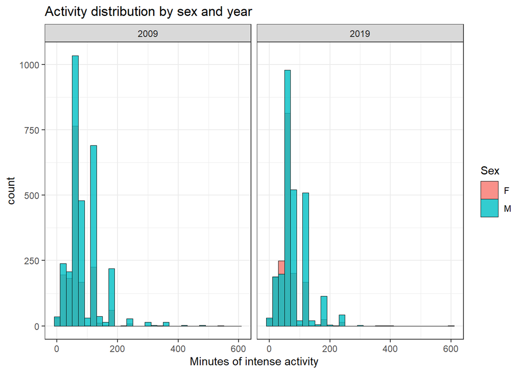

Between 2009 and 2019 the same pronounced right skew and gender gap persist: men accumulate more minutes of intense activity, while women, despite a slight increase in variability, continue to exhibit substantially lower average values and counts.

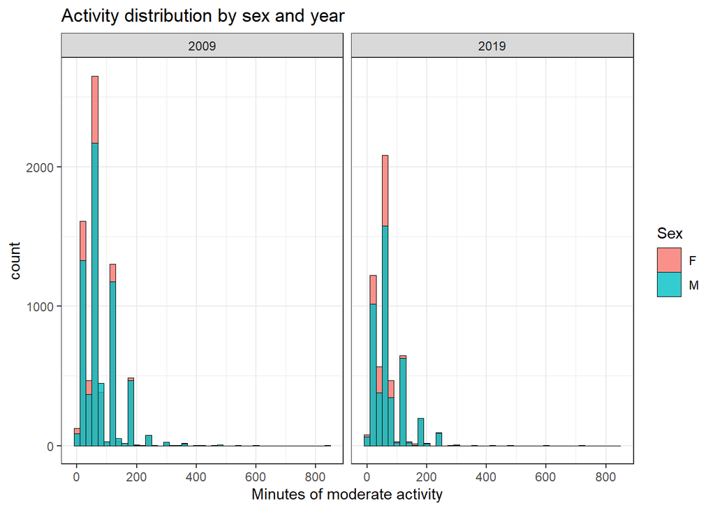

In both 2009 and 2019 the distributions of weekly minutes of moderate activity are strongly right-skewed, with the bulk of respondents clustered below about 150 minutes and a long tail toward higher values. In each year, women outnumber men in nearly every time bin.  
**Barplots of the selected variables**  
Since the variables related to days have a limited and meaningful number of discrete values, it makes more sense to obtain a clearer representation trough barplots with a bar for each number of days.

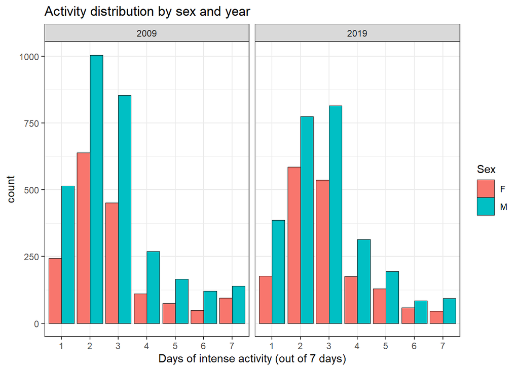

In both 2009 and 2019 the distribution of intense‐activity days is unimodal at 2–3 days per week; most people do intense activity only a few days a week, men more so than women, with little change in the general shape in these specific years.

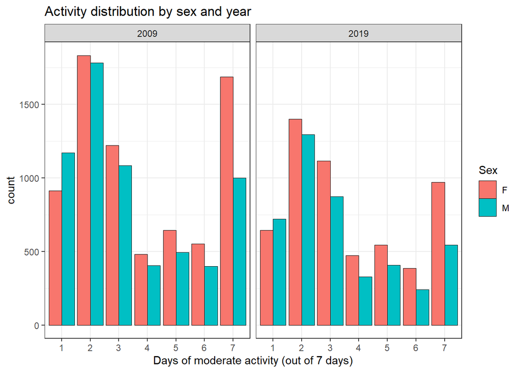

In both 2009 and 2019, moderate activity days cluster tightly in the 1–3-day range, peaking at 2 days per week, with frequencies plunging for 4–6 days and a smaller rebound at 7 days. Women outnumber men at nearly every day-count except the 1-day category.

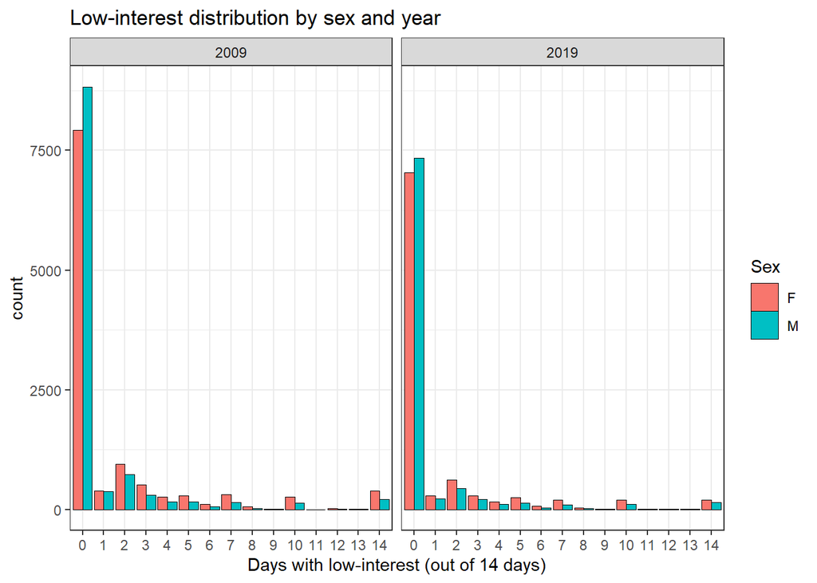

In both 2009 and 2019 the distribution of low‐interest days is extremely right‐skewed: the vast majority of people report 0 days of low interest in the past two weeks, with a sharp drop to 1–2 days and then a long, sparse tail all the way out to 14 days.

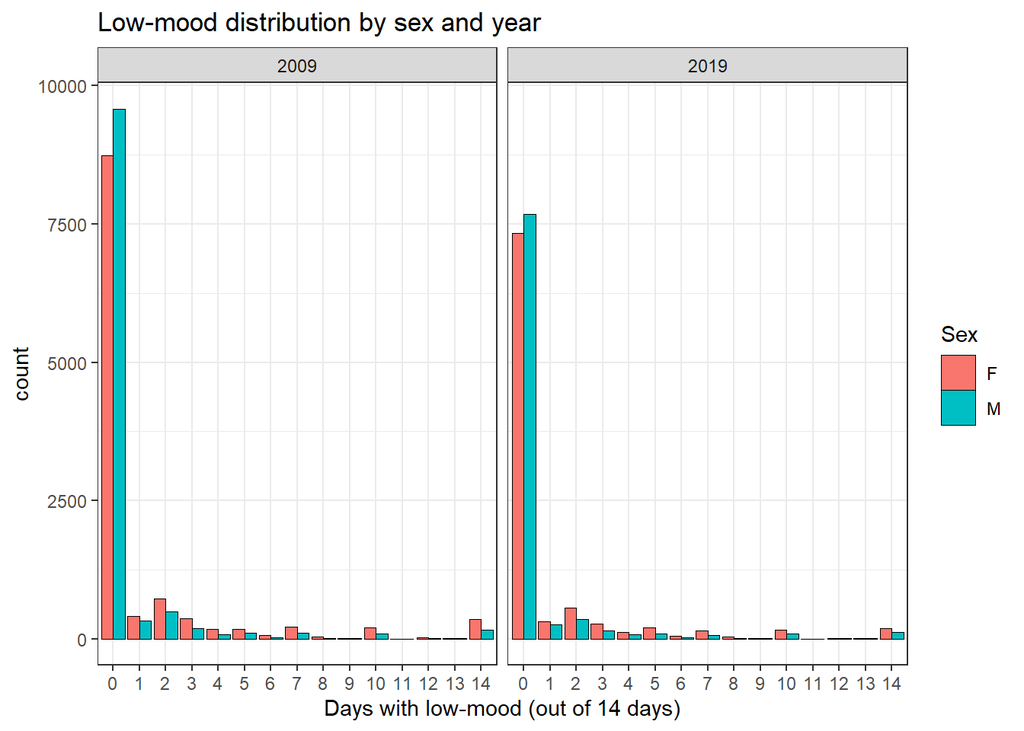

As for `s12_poco_inter_gg`, also `s12_giu_morale_gg` shows a distribution where most people in both years experience no low-mood days, and the shape of the distribution remains nearly unchanged across sexes and over time.  
The variables `s02_tlib_attiv_inte_gg`, `s02_attiv_moder_gg`, `s12_poco_inter_gg`, and `s12_giu_morale_gg` pertain to different intervals (the first two are calculated over 7 days, while the last two are calculated over 14 days), so we should normalize the data in order to have comparable graphs.

```r
z_s02_tlib_attiv_inte_gg = scale(passi_benessere$s02_tlib_attiv_inte_gg)
z_s02_attiv_moder_gg = scale(passi_benessere$s02_attiv_moder_gg)
z_s12_poco_inter_gg = scale(passi_benessere$s12_poco_inter_gg)
z_s12_giu_morale_gg = scale(passi_benessere$s12_giu_morale_gg)
```

**Histograms of the selected variables with standardized values**

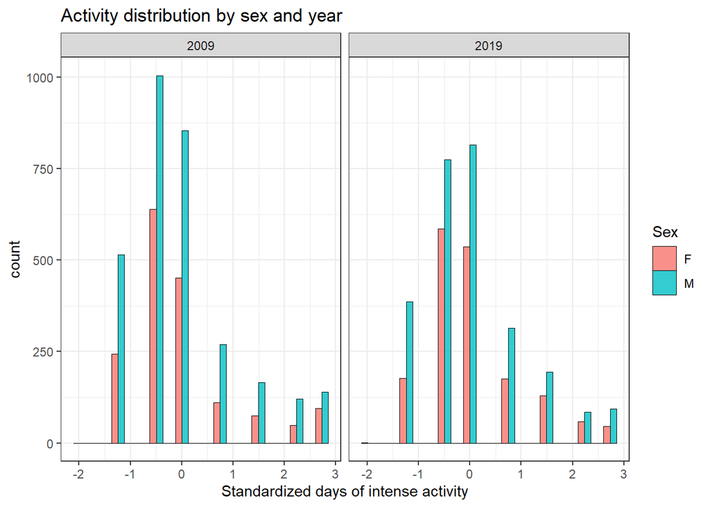

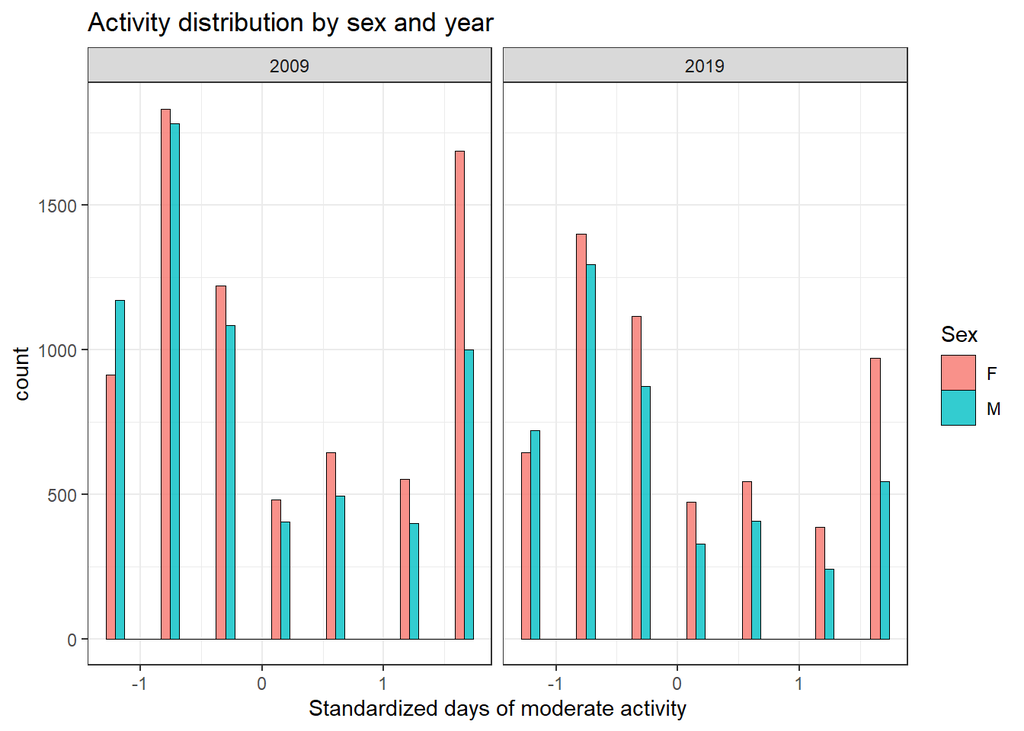

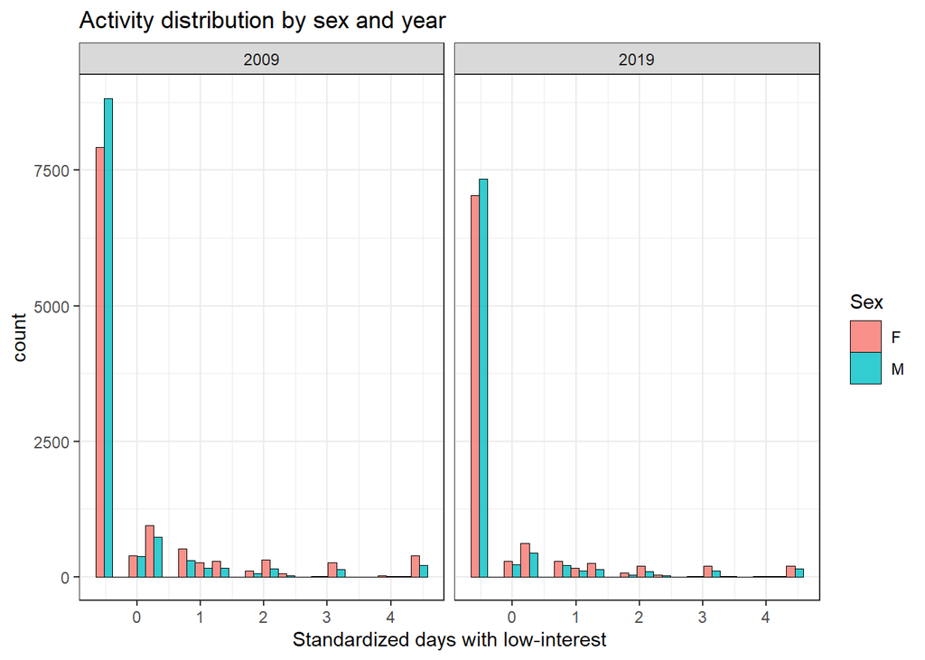

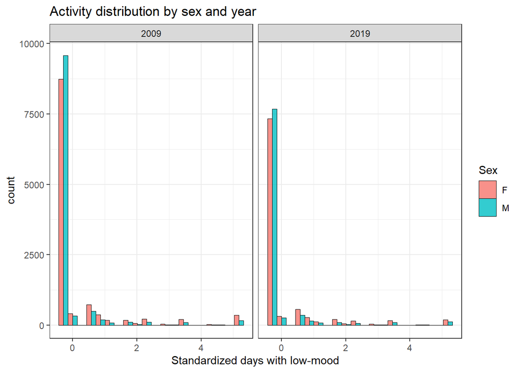

**Data frames with the proportions/morbidity rates of `s12_poco_inter_gg` and `s12_giu_morale_gg`**  
1) Grouping by region

```r
df_inter_reg = passi_benessere %>% filter(!is.na(s12_poco_inter_gg)) %>%
  group_by(regione, s12_poco_inter_gg) %>%
  summarise(n = n(), .groups = "drop_last") %>%   # Counting how many people have a specific n of days with low-interest and then dropping this                                                                       number to go to the next one, remaining in the same region
  mutate(total = sum(n), prop  = n / total) %>%   # Total for each region and proportion for each number of days with low-interest
  dplyr::select(regione, s12_poco_inter_gg, prop)
df_inter_reg
```

```
## # A tibble: 269 × 3
## # Groups:   regione [21]
##    regione s12_poco_inter_gg    prop
##    <fct>               <int>   <dbl>
##  1 Abruzzo                 0 0.806
##  2 Abruzzo                 1 0.0233
##  3 Abruzzo                 2 0.0474
##  4 Abruzzo                 3 0.0289
##  5 Abruzzo                 4 0.0113
##  6 Abruzzo                 5 0.0177
##  7 Abruzzo                 6 0.00804
##  8 Abruzzo                 7 0.0201
##  9 Abruzzo                 8 0.00482
## 10 Abruzzo                10 0.0145
## # ℹ 259 more rows
```

```r
df_morale_reg = passi_benessere %>% filter(!is.na(s12_giu_morale_gg)) %>%
  group_by(regione, s12_giu_morale_gg) %>%
  summarise(n = n(), .groups = "drop_last") %>%    # Counting how many people have a specific n of days with low-mood and then dropping this number                                                                    to go to the next one, remaining in the same region
  mutate(total = sum(n), prop  = n / total) %>%    # Total for each region and proportion for each number of days with low-mood
  dplyr::select(regione, s12_giu_morale_gg, prop)
df_morale_reg
```

```
## # A tibble: 268 × 3
## # Groups:   regione [21]
##    regione s12_giu_morale_gg    prop
##    <fct>               <int>   <dbl>
##  1 Abruzzo                 0 0.839
##  2 Abruzzo                 1 0.0286
##  3 Abruzzo                 2 0.0405
##  4 Abruzzo                 3 0.0222
##  5 Abruzzo                 4 0.00874
##  6 Abruzzo                 5 0.00874
##  7 Abruzzo                 6 0.00318
##  8 Abruzzo                 7 0.0127
##  9 Abruzzo                 8 0.00238
## 10 Abruzzo                10 0.0135
## # ℹ 258 more rows
```

*Graphical representation of the previous proportions zooming in the interval between 0% and 20%*

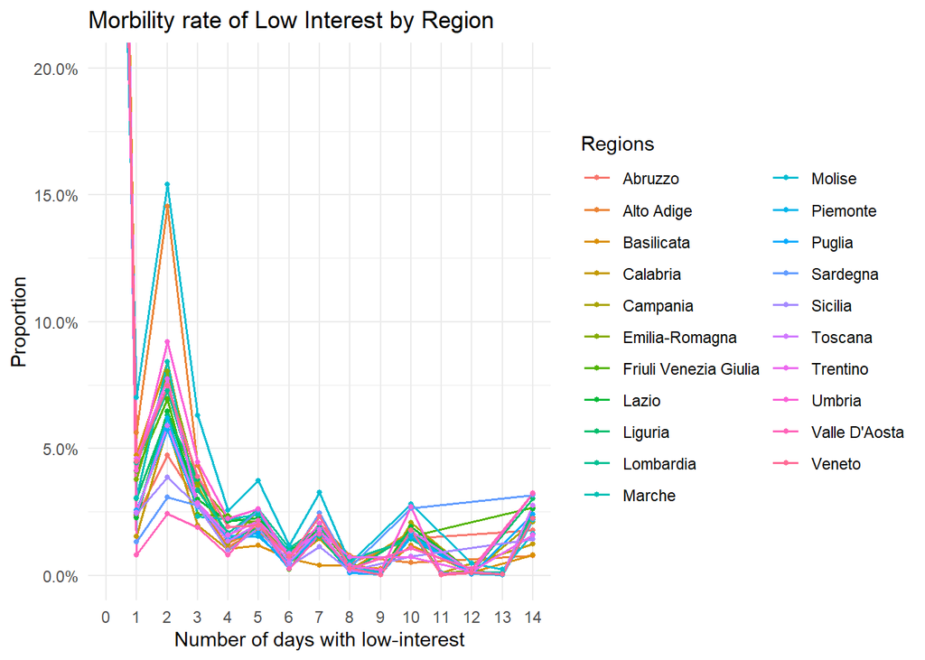

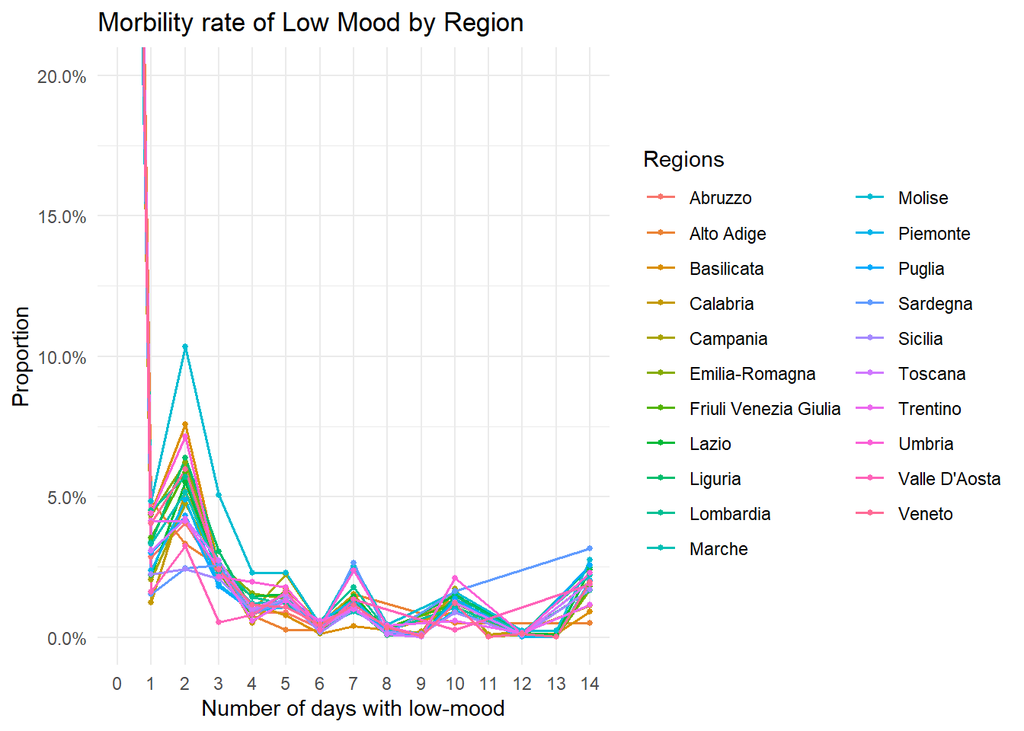

Overall, every region follows nearly the same pattern, indicating that most people experience no low-mood days, a small share have one or two days, and very few endure longer periods.  
2) Grouping by age

```r
df_inter_eta = passi_benessere %>% filter(!is.na(s12_poco_inter_gg)) %>%
  group_by(claeta3, s12_poco_inter_gg) %>%
  summarise(n = n(), .groups = "drop_last") %>%
  mutate(total = sum(n), prop  = n / total) %>%     # Total for each level of age and proportion for each number of days with low-interest
  dplyr::select(claeta3, s12_poco_inter_gg, prop)
df_inter_eta
```

```
## # A tibble: 45 × 3
## # Groups:   claeta3 [3]
##    claeta3 s12_poco_inter_gg     prop
##    <fct>               <int>    <dbl>
##  1 18-34                   0 0.747
##  2 18-34                   1 0.0398
##  3 18-34                   2 0.0766
##  4 18-34                   3 0.0353
##  5 18-34                   4 0.0208
##  6 18-34                   5 0.0217
##  7 18-34                   6 0.00740
##  8 18-34                   7 0.0201
##  9 18-34                   8 0.00187
## 10 18-34                   9 0.000802
## # ℹ 35 more rows
```

```r
df_morale_eta = passi_benessere %>% filter(!is.na(s12_giu_morale_gg)) %>%
  group_by(claeta3, s12_giu_morale_gg) %>%
  summarise(n = n(), .groups = "drop_last") %>%
  mutate(total = sum(n), prop  = n / total) %>%     # Total for each level of age and proportion for each number of days with low-mood
  dplyr::select(claeta3, s12_giu_morale_gg, prop)
df_morale_eta
```

```
## # A tibble: 45 × 3
## # Groups:   claeta3 [3]
##    claeta3 s12_giu_morale_gg     prop
##    <fct>               <int>    <dbl>
##  1 18-34                   0 0.813
##  2 18-34                   1 0.0402
##  3 18-34                   2 0.0551
##  4 18-34                   3 0.0249
##  5 18-34                   4 0.0129
##  6 18-34                   5 0.0143
##  7 18-34                   6 0.00364
##  8 18-34                   7 0.0134
##  9 18-34                   8 0.00213
## 10 18-34                   9 0.000444
## # ℹ 35 more rows
```

*Graphical representation of the previous proportions zooming in the interval between 0% and 20%*

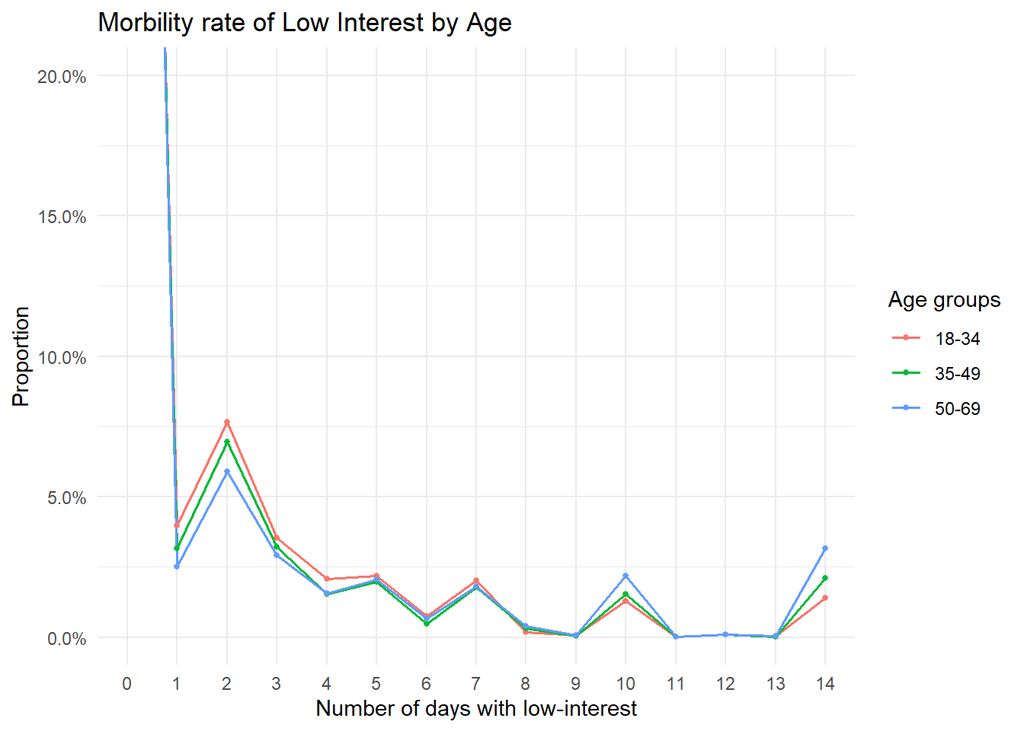

All three age groups show the same highly right-skewed pattern in days of low interest over 14 days. Differences between age groups are minimal: the youngest edge out the others at the 2-day peak, while the oldest show marginally higher proportions at the longest periods.

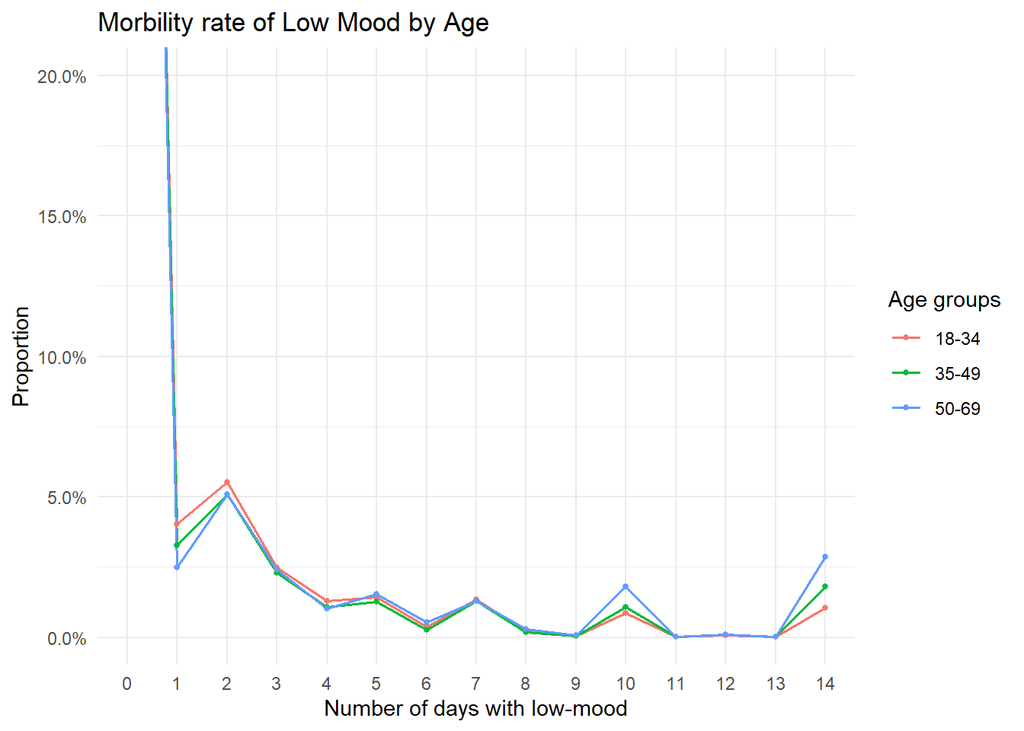

As above, differences by age are minimal: the youngest group shows the tallest 2-day peak, while the oldest group edges out at the extreme 14-day mark.  
3) Grouping by sex

```r
df_inter_sesso = passi_benessere %>% filter(!is.na(s12_poco_inter_gg)) %>%
  group_by(sesso_intervistato, s12_poco_inter_gg) %>%
  summarise(n = n(), .groups = "drop_last") %>%
  mutate(total = sum(n), prop  = n / total) %>%               # Total for each sex and proportion for each number of days with low-interest
  dplyr::select(sesso_intervistato, s12_poco_inter_gg, prop)
df_inter_sesso
```

```
## # A tibble: 30 × 3
## # Groups:   sesso_intervistato [2]
##    sesso_intervistato s12_poco_inter_gg     prop
##    <fct>                          <int>    <dbl>
##  1 F                                  0 0.718
##  2 F                                  1 0.0326
##  3 F                                  2 0.0755
##  4 F                                  3 0.0383
##  5 F                                  4 0.0199
##  6 F                                  5 0.0257
##  7 F                                  6 0.00831
##  8 F                                  7 0.0241
##  9 F                                  8 0.00437
## 10 F                                  9 0.000672
## # ℹ 20 more rows
```

```r
df_morale_sesso = passi_benessere %>% filter(!is.na(s12_giu_morale_gg)) %>%
  group_by(sesso_intervistato, s12_giu_morale_gg) %>%
  summarise(n = n(), .groups = "drop_last") %>%
  mutate(total = sum(n), prop  = n / total) %>%               # Total for each sex and proportion for each number of days with low-mood
  dplyr::select(sesso_intervistato, s12_giu_morale_gg, prop)
df_morale_sesso
```

```
## # A tibble: 30 × 3
## # Groups:   sesso_intervistato [2]
##    sesso_intervistato s12_giu_morale_gg     prop
##    <fct>                          <int>    <dbl>
##  1 F                                  0 0.770
##  2 F                                  1 0.0346
##  3 F                                  2 0.0614
##  4 F                                  3 0.0307
##  5 F                                  4 0.0145
##  6 F                                  5 0.0179
##  7 F                                  6 0.00551
##  8 F                                  7 0.0175
##  9 F                                  8 0.00335
## 10 F                                  9 0.000575
## # ℹ 20 more rows
```

*Graphical representation of the previous proportions zooming in the interval between 0% and 20%*

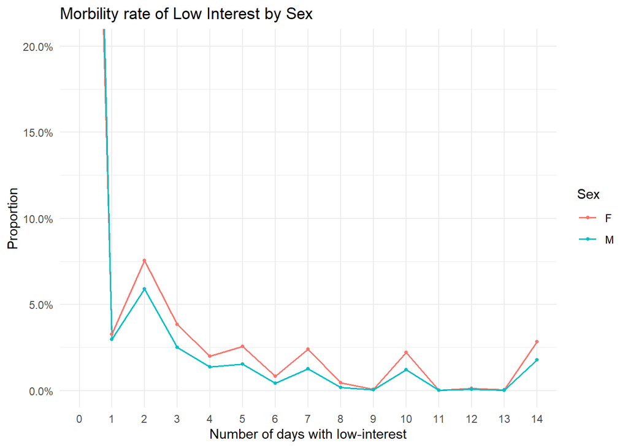

Throughout most of the range, women report a higher share of low-interest days than men, but the overall shape of the distribution is the same for both.

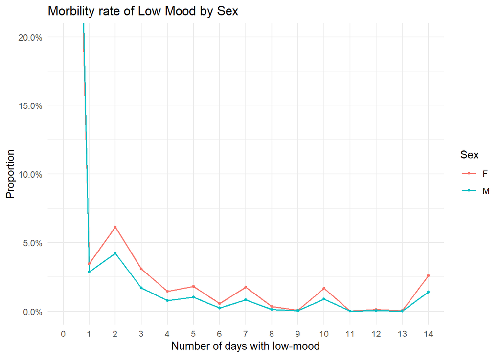

## 5.2 Fitting Regression Models

Poisson regression is a special case of a generalized linear model (GLM) with a log link. If we let Y be the count outcome (number of days with low-interest or low-mood) and X a single predictor, the model is: log(E[Y | X]) = α + βX. Equivalently, λ(X) = E[Y | X] = exp(α + βX) = exp(α) · [exp(β)]^X  
Baseline mean: • When X = 0, λ(0) = exp(α).  
Multiplicative effect: • A one-unit increase in X multiplies the mean by exp(β): λ(X + 1) = exp(α + β(X + 1)) = λ(X) · exp(β).  
Sign of β:  
• If β > 0, then exp(β) > 1, so the expected count increases as X increases.  
• If β < 0, then 0 < exp(β) < 1, so the expected count decreases as X increases.  
Thus, on the log scale the effect is additive (β units change in the log-mean per unit of X), but on the original count scale it is multiplicative (exp(β) change in the mean per unit of X).  
Since we have log scale and categorical predictors, each coefficient associated to a non-baseline level represents the difference in the log-mean from the baseline and the effect is additive.  
Our response variable is a count over a 14-day window and that period is constant for all the cases so we don’t need an offset (it will be absorbed by the intercept). If instead the “exposure” (i.e. the length of the time interval over which we measure the count) varies across units, we need to specify ‘offset’.  
*Let’s see graphically if there is an association between the ‘Days with low-interest’ and the categorical predictors*

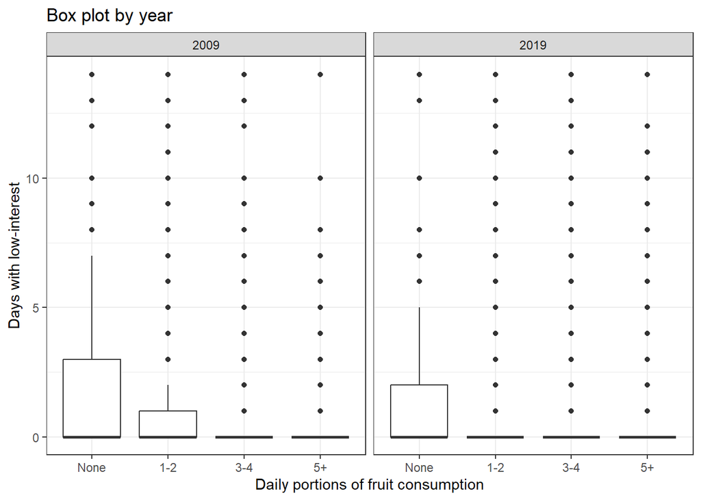

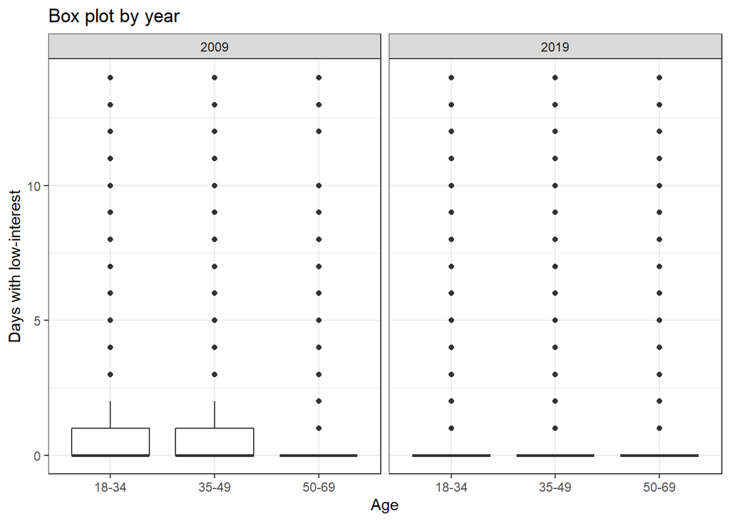

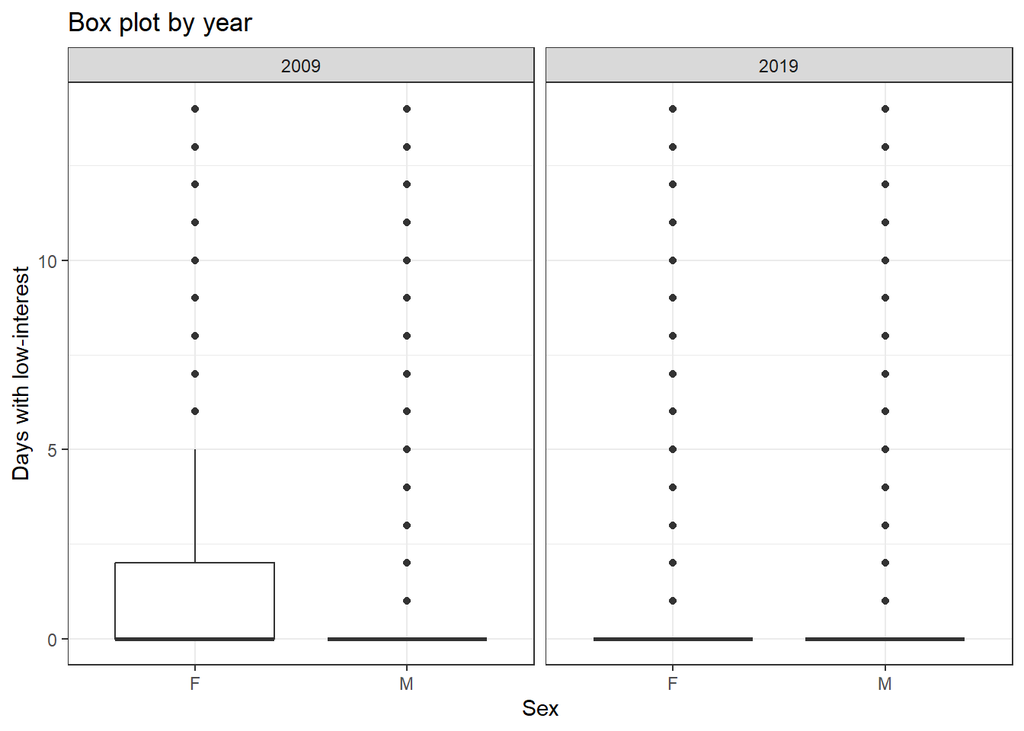

All three panels show that most people report zero low-interest days, with medians at or very near 0 and long tails of outliers stretching up toward 14 days. Overall, low-interest days fall for everyone from 2009 to 2019, and groups with healthier habits (eat more fruit), older age and men tend to report slightly fewer days of low interest.  
**Regression models with `s12_poco_inter_gg` as dependent variable**

```r
m0_inter = glm(s12_poco_inter_gg ~ s02_tlib_attiv_inte_gg + s04_consu_frutta + claeta3 + sesso_intervistato,
         family = poisson(link ="log"), data = passi_benessere%>% filter(if_all(everything(), ~ !is.na(.)))) # Taking only the rows for which all columns are non-NA using an anonymous function ~, so that the models have equal sample size and can be compared with anova
summary(m0_inter)
```

```
##
## Call:
## glm(formula = s12_poco_inter_gg ~ s02_tlib_attiv_inte_gg + s04_consu_frutta +
##     claeta3 + sesso_intervistato, family = poisson(link = "log"),
##     data = passi_benessere %>% filter(if_all(everything(), ~!is.na(.))))
##
## Coefficients:
##                         Estimate Std. Error z value Pr(>|z|)
## (Intercept)             1.150822   0.075777  15.187  < 2e-16 ***
## s02_tlib_attiv_inte_gg -0.034354   0.009687  -3.546  0.00039 ***
## s04_consu_frutta1-2    -0.572225   0.071638  -7.988 1.37e-15 ***
## s04_consu_frutta3-4    -0.782198   0.072751 -10.752  < 2e-16 ***
## s04_consu_frutta5+     -0.653003   0.080350  -8.127 4.40e-16 ***
## claeta335-49           -0.185834   0.030304  -6.132 8.66e-10 ***
## claeta350-69           -0.382655   0.037657 -10.162  < 2e-16 ***
## sesso_intervistatoM    -0.390592   0.027279 -14.318  < 2e-16 ***
## ---
## Signif. codes:  0 '***' 0.001 '**' 0.01 '*' 0.05 '.' 0.1 ' ' 1
##
## (Dispersion parameter for poisson family taken to be 1)
##
##     Null deviance: 17492  on 5240  degrees of freedom
## Residual deviance: 17020  on 5233  degrees of freedom
## AIC: 21298
##
## Number of Fisher Scoring iterations: 6
```

```r
m1_inter = glm(s12_poco_inter_gg ~ s02_tlib_attiv_inte_gg + s02_attiv_moder_gg + s04_consu_frutta + claeta3 + sesso_intervistato,
         family = poisson(link = "log"), data = passi_benessere%>% filter(if_all(everything(), ~ !is.na(.))))
summary(m1_inter)
```

```
##
## Call:
## glm(formula = s12_poco_inter_gg ~ s02_tlib_attiv_inte_gg + s02_attiv_moder_gg +
##     s04_consu_frutta + claeta3 + sesso_intervistato, family = poisson(link = "log"),
##     data = passi_benessere %>% filter(if_all(everything(), ~!is.na(.))))
##
## Coefficients:
##                         Estimate Std. Error z value Pr(>|z|)
## (Intercept)             1.117396   0.077946  14.335  < 2e-16 ***
## s02_tlib_attiv_inte_gg -0.038034   0.009882  -3.849 0.000119 ***
## s02_attiv_moder_gg      0.012443   0.006734   1.848 0.064616 .
## s04_consu_frutta1-2    -0.571741   0.071640  -7.981 1.45e-15 ***
## s04_consu_frutta3-4    -0.783158   0.072755 -10.764  < 2e-16 ***
## s04_consu_frutta5+     -0.655719   0.080366  -8.159 3.37e-16 ***
## claeta335-49           -0.185161   0.030308  -6.109 1.00e-09 ***
## claeta350-69           -0.384191   0.037666 -10.200  < 2e-16 ***
## sesso_intervistatoM    -0.386205   0.027387 -14.102  < 2e-16 ***
## ---
## Signif. codes:  0 '***' 0.001 '**' 0.01 '*' 0.05 '.' 0.1 ' ' 1
##
## (Dispersion parameter for poisson family taken to be 1)
##
##     Null deviance: 17492  on 5240  degrees of freedom
## Residual deviance: 17017  on 5232  degrees of freedom
## AIC: 21297
##
## Number of Fisher Scoring iterations: 6
```

Baseline: a female 18–34 year‐old with 0 days of moderate or intense activity and without daily fruit consumption. Intense activity and fruit consumption show statistically significant reductions in low‐interest days. Moderate activity has only a weak, not strongly significant positive effect here, but i will keep it since AIC decreases a little. Older age and male sex are both protective.  
**Checking for correlation between numerical predictors**

```r
cor.test(passi_benessere$s02_tlib_attiv_inte_gg, passi_benessere$s02_attiv_moder_gg,
         use = "complete.obs", method = "pearson") # Or method = "Spearman"
```

```
##
##  Pearson's product-moment correlation
##
## data:  passi_benessere$s02_tlib_attiv_inte_gg and passi_benessere$s02_attiv_moder_gg
## t = 18.237, df = 5487, p-value < 2.2e-16
## alternative hypothesis: true correlation is not equal to 0
## 95 percent confidence interval:
##  0.2139577 0.2638472
## sample estimates:
##       cor
## 0.2390602
```

There is a modest positive relationship (0.24) between the number of days of intense activity (`s02_tlib_attiv_inte_gg`) and the number of days of moderate activity (`s02_attiv_moder_gg`). There is a correlation, but it isn’t very strong. With p-value < 2.2e-16, the null hypothesis (correlation = 0) is rejected with strong evidence, so the correlation is statistically significant and we are 95% confidence that the true correlation falls in the range between 0.21 and 0.26. ρ of Spearman could also be used in order to investigate the monotonous association between ranks and guarantee robustness because it is not affected by extreme outliers. But in thi case the ruslts are quite similar (ρ = 0.22), so I will keep the raw correlation.

```r
m1_inter_cor = glm(s12_poco_inter_gg ~ s02_tlib_attiv_inte_gg*s02_attiv_moder_gg + s04_consu_frutta + claeta3 + sesso_intervistato,
            family = poisson(link="log"), data = passi_benessere%>% filter(if_all(everything(), ~ !is.na(.))))
summary(m1_inter_cor)
```

```
##
## Call:
## glm(formula = s12_poco_inter_gg ~ s02_tlib_attiv_inte_gg * s02_attiv_moder_gg +
##     s04_consu_frutta + claeta3 + sesso_intervistato, family = poisson(link = "log"),
##     data = passi_benessere %>% filter(if_all(everything(), ~!is.na(.))))
##
## Coefficients:
##                                            Estimate Std. Error z value Pr(>|z|)
## (Intercept)                                1.256230   0.090309  13.910  < 2e-16
## s02_tlib_attiv_inte_gg                    -0.091365   0.020332  -4.494 7.00e-06
## s02_attiv_moder_gg                        -0.023700   0.013700  -1.730  0.08364
## s04_consu_frutta1-2                       -0.570315   0.071641  -7.961 1.71e-15
## s04_consu_frutta3-4                       -0.780457   0.072764 -10.726  < 2e-16
## s04_consu_frutta5+                        -0.655934   0.080379  -8.160 3.34e-16
## claeta335-49                              -0.188928   0.030335  -6.228 4.72e-10
## claeta350-69                              -0.388337   0.037701 -10.300  < 2e-16
## sesso_intervistatoM                       -0.387415   0.027390 -14.144  < 2e-16
## s02_tlib_attiv_inte_gg:s02_attiv_moder_gg  0.013121   0.004314   3.041  0.00236
##
## (Intercept)                               ***
## s02_tlib_attiv_inte_gg                    ***
## s02_attiv_moder_gg                        .
## s04_consu_frutta1-2                       ***
## s04_consu_frutta3-4                       ***
## s04_consu_frutta5+                        ***
## claeta335-49                              ***
## claeta350-69                              ***
## sesso_intervistatoM                       ***
## s02_tlib_attiv_inte_gg:s02_attiv_moder_gg **
## ---
## Signif. codes:  0 '***' 0.001 '**' 0.01 '*' 0.05 '.' 0.1 ' ' 1
##
## (Dispersion parameter for poisson family taken to be 1)
##
##     Null deviance: 17492  on 5240  degrees of freedom
## Residual deviance: 17007  on 5231  degrees of freedom
## AIC: 21290
##
## Number of Fisher Scoring iterations: 6
```

```r
anova(m0_inter, m1_inter, m1_inter_cor, test= 'LRT')
```

[output not shown]

The interaction of the numerical predictors significantly improves the model’s fit and should be considered: it suggests that the association between `s02_attiv_moder_gg` and `s12_poco_inter_gg` varies depending on `s02_tlib_attiv_inte_gg`.  
*Let’s see graphically if there is an association between the ‘s12_giu_morale_gg’ and the categorical predictors*

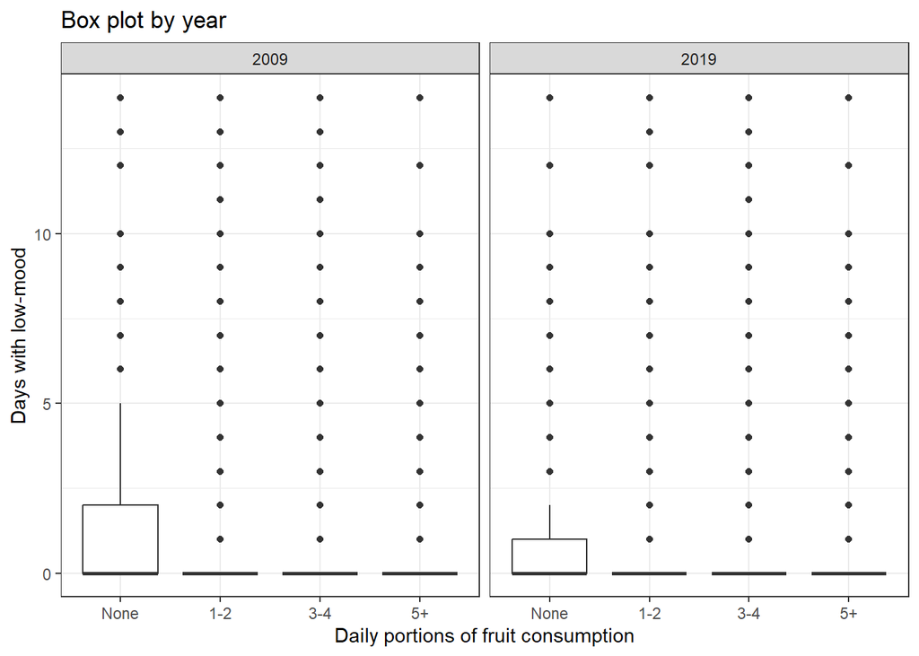

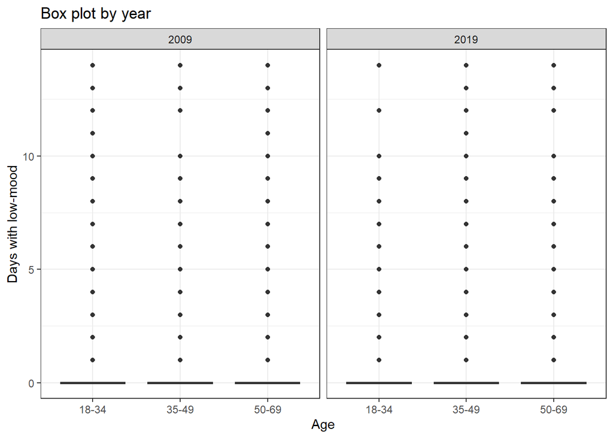

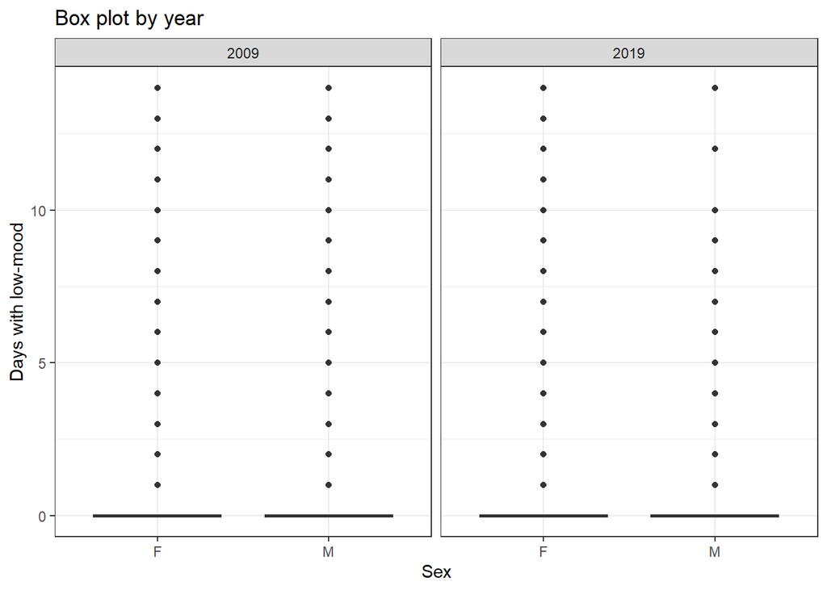

```r
m2_morale = glm(s12_giu_morale_gg ~  s02_tlib_attiv_inte_gg + s04_consu_frutta + claeta3 + sesso_intervistato,
         family = poisson(link="log"), data = passi_benessere%>% filter(if_all(everything(), ~ !is.na(.)))) # Taking only the rows for which all columns are non-NA, so that the models have equal sample sizes and can be compared with anova
summary(m2_morale)
```

```
##
## Call:
## glm(formula = s12_giu_morale_gg ~ s02_tlib_attiv_inte_gg + s04_consu_frutta +
##     claeta3 + sesso_intervistato, family = poisson(link = "log"),
##     data = passi_benessere %>% filter(if_all(everything(), ~!is.na(.))))
##
## Coefficients:
##                         Estimate Std. Error z value Pr(>|z|)
## (Intercept)             0.916072   0.087262  10.498  < 2e-16 ***
## s02_tlib_attiv_inte_gg  0.009784   0.011237   0.871 0.383909
## s04_consu_frutta1-2    -0.778975   0.082787  -9.409  < 2e-16 ***
## s04_consu_frutta3-4    -0.979119   0.083968 -11.661  < 2e-16 ***
## s04_consu_frutta5+     -0.834160   0.092591  -9.009  < 2e-16 ***
## claeta335-49           -0.127312   0.037261  -3.417 0.000634 ***
## claeta350-69           -0.138115   0.043441  -3.179 0.001476 **
## sesso_intervistatoM    -0.706103   0.033432 -21.121  < 2e-16 ***
## ---
## Signif. codes:  0 '***' 0.001 '**' 0.01 '*' 0.05 '.' 0.1 ' ' 1
##
## (Dispersion parameter for poisson family taken to be 1)
##
##     Null deviance: 14388  on 5240  degrees of freedom
## Residual deviance: 13817  on 5233  degrees of freedom
## AIC: 16907
##
## Number of Fisher Scoring iterations: 6
```

```r
m3_morale = glm(s12_giu_morale_gg ~ s02_attiv_moder_gg + s04_consu_frutta + claeta3 + sesso_intervistato,
         family = poisson(link="log"), data = passi_benessere%>% filter(if_all(everything(), ~ !is.na(.))))
summary(m3_morale)
```

```
##
## Call:
## glm(formula = s12_giu_morale_gg ~ s02_attiv_moder_gg + s04_consu_frutta +
##     claeta3 + sesso_intervistato, family = poisson(link = "log"),
##     data = passi_benessere %>% filter(if_all(everything(), ~!is.na(.))))
##
## Coefficients:
##                      Estimate Std. Error z value Pr(>|z|)
## (Intercept)          0.899673   0.086318  10.423  < 2e-16 ***
## s02_attiv_moder_gg   0.012375   0.007925   1.562 0.118398
## s04_consu_frutta1-2 -0.778843   0.082787  -9.408  < 2e-16 ***
## s04_consu_frutta3-4 -0.979548   0.083969 -11.666  < 2e-16 ***
## s04_consu_frutta5+  -0.835112   0.092564  -9.022  < 2e-16 ***
## claeta335-49        -0.127207   0.037263  -3.414 0.000641 ***
## claeta350-69        -0.138662   0.043412  -3.194 0.001403 **
## sesso_intervistatoM -0.701651   0.033551 -20.913  < 2e-16 ***
## ---
## Signif. codes:  0 '***' 0.001 '**' 0.01 '*' 0.05 '.' 0.1 ' ' 1
##
## (Dispersion parameter for poisson family taken to be 1)
##
##     Null deviance: 14388  on 5240  degrees of freedom
## Residual deviance: 13815  on 5233  degrees of freedom
## AIC: 16905
##
## Number of Fisher Scoring iterations: 6
```

```r
m4_morale = glm(s12_giu_morale_gg ~ s04_consu_frutta + claeta3 + sesso_intervistato,
         family = poisson(link="log"), data = passi_benessere%>% filter(if_all(everything(), ~ !is.na(.))))
summary(m4_morale)
```

```
##
## Call:
## glm(formula = s12_giu_morale_gg ~ s04_consu_frutta + claeta3 +
##     sesso_intervistato, family = poisson(link = "log"), data = passi_benessere %>%
##     filter(if_all(everything(), ~!is.na(.))))
##
## Coefficients:
##                     Estimate Std. Error z value Pr(>|z|)
## (Intercept)          0.94258    0.08175  11.530  < 2e-16 ***
## s04_consu_frutta1-2 -0.77963    0.08278  -9.418  < 2e-16 ***
## s04_consu_frutta3-4 -0.97815    0.08396 -11.650  < 2e-16 ***
## s04_consu_frutta5+  -0.83122    0.09253  -8.983  < 2e-16 ***
## claeta335-49        -0.12740    0.03726  -3.419 0.000628 ***
## claeta350-69        -0.13622    0.04339  -3.140 0.001691 **
## sesso_intervistatoM -0.70597    0.03343 -21.116  < 2e-16 ***
## ---
## Signif. codes:  0 '***' 0.001 '**' 0.01 '*' 0.05 '.' 0.1 ' ' 1
##
## (Dispersion parameter for poisson family taken to be 1)
##
##     Null deviance: 14388  on 5240  degrees of freedom
## Residual deviance: 13817  on 5234  degrees of freedom
## AIC: 16905
##
## Number of Fisher Scoring iterations: 6
```

```r
dispersiontest(m1_inter_cor, trafo=1,alternative = "two.sided")
```

```
##
##  Dispersion test
##
## data:  m1_inter_cor
## z = 16.487, p-value < 2.2e-16
## alternative hypothesis: true alpha is not equal to 0
## sample estimates:
##   alpha
## 4.50108
```

```r
dispersiontest(m4_morale, trafo=1,alternative = "two.sided")
```

```
##
##  Dispersion test
##
## data:  m4_morale
## z = 12.814, p-value < 2.2e-16
## alternative hypothesis: true alpha is not equal to 0
## sample estimates:
##    alpha
## 4.488941
```

Poisson distribution has identical mean and variance, but in this case both the models have over-dispersion because alpha > 1 (dispersion parameter) with strong statistical evidence (p-value < 2.2e-16). There is evident overdispersion in the Poisson model: the residuals vary much more than the model expects. The Negative Binomial Model corrects this issue by introducing the θ parameter and produces more realistic standard errors.  
**Fitting negative-binomial regression models**

```r
m1_inter_cor_nb = glm.nb(s12_poco_inter_gg ~ s02_tlib_attiv_inte_gg*s02_attiv_moder_gg + s04_consu_frutta + claeta3 + sesso_intervistato,
                   link="log", data = passi_benessere%>% filter(if_all(everything(), ~ !is.na(.))))
summary(m1_inter_cor_nb)
```

```
##
## Call:
## glm.nb(formula = s12_poco_inter_gg ~ s02_tlib_attiv_inte_gg *
##     s02_attiv_moder_gg + s04_consu_frutta + claeta3 + sesso_intervistato,
##     data = passi_benessere %>% filter(if_all(everything(), ~!is.na(.))),
##     link = "log", init.theta = 0.1725503265)
##
## Coefficients:
##                                           Estimate Std. Error z value Pr(>|z|)
## (Intercept)                                1.26782    0.29443   4.306 1.66e-05
## s02_tlib_attiv_inte_gg                    -0.07968    0.05180  -1.538  0.12400
## s02_attiv_moder_gg                        -0.02009    0.03692  -0.544  0.58640
## s04_consu_frutta1-2                       -0.54821    0.25486  -2.151  0.03147
## s04_consu_frutta3-4                       -0.78508    0.25615  -3.065  0.00218
## s04_consu_frutta5+                        -0.66782    0.27274  -2.449  0.01434
## claeta335-49                              -0.22419    0.08290  -2.704  0.00685
## claeta350-69                              -0.44004    0.09499  -4.632 3.62e-06
## sesso_intervistatoM                       -0.41691    0.07412  -5.625 1.86e-08
## s02_tlib_attiv_inte_gg:s02_attiv_moder_gg  0.01073    0.01127   0.952  0.34095
##
## (Intercept)                               ***
## s02_tlib_attiv_inte_gg
## s02_attiv_moder_gg
## s04_consu_frutta1-2                       *
## s04_consu_frutta3-4                       **
## s04_consu_frutta5+                        *
## claeta335-49                              **
## claeta350-69                              ***
## sesso_intervistatoM                       ***
## s02_tlib_attiv_inte_gg:s02_attiv_moder_gg
## ---
## Signif. codes:  0 '***' 0.001 '**' 0.01 '*' 0.05 '.' 0.1 ' ' 1
##
## (Dispersion parameter for Negative Binomial(0.1726) family taken to be 1)
##
##     Null deviance: 3311.1  on 5240  degrees of freedom
## Residual deviance: 3239.3  on 5231  degrees of freedom
## AIC: 12604
##
## Number of Fisher Scoring iterations: 1
##
##
##               Theta:  0.17255
##           Std. Err.:  0.00652
##
##  2 x log-likelihood:  -12582.11400
```

```r
m4_morale_nb = glm.nb(s12_giu_morale_gg ~ s04_consu_frutta + claeta3 + sesso_intervistato,
               link="log", data = passi_benessere%>% filter(if_all(everything(), ~ !is.na(.))))
summary(m4_morale_nb)
```

```
##
## Call:
## glm.nb(formula = s12_giu_morale_gg ~ s04_consu_frutta + claeta3 +
##     sesso_intervistato, data = passi_benessere %>% filter(if_all(everything(),
##     ~!is.na(.))), link = "log", init.theta = 0.1272468364)
##
## Coefficients:
##                     Estimate Std. Error z value Pr(>|z|)
## (Intercept)          1.00653    0.29727   3.386 0.000709 ***
## s04_consu_frutta1-2 -0.78914    0.29691  -2.658 0.007865 **
## s04_consu_frutta3-4 -0.99816    0.29840  -3.345 0.000823 ***
## s04_consu_frutta5+  -0.90128    0.31775  -2.836 0.004561 **
## claeta335-49        -0.17189    0.09772  -1.759 0.078584 .
## claeta350-69        -0.20165    0.11085  -1.819 0.068891 .
## sesso_intervistatoM -0.73193    0.08651  -8.460  < 2e-16 ***
## ---
## Signif. codes:  0 '***' 0.001 '**' 0.01 '*' 0.05 '.' 0.1 ' ' 1
##
## (Dispersion parameter for Negative Binomial(0.1272) family taken to be 1)
##
##     Null deviance: 2654.2  on 5240  degrees of freedom
## Residual deviance: 2567.4  on 5234  degrees of freedom
## AIC: 9813
##
## Number of Fisher Scoring iterations: 1
##
##
##               Theta:  0.12725
##           Std. Err.:  0.00553
##
##  2 x log-likelihood:  -9797.04500
```

```r
lrtest(m1_inter_cor, m1_inter_cor_nb)
```

```
## Likelihood ratio test
##
## Model 1: s12_poco_inter_gg ~ s02_tlib_attiv_inte_gg * s02_attiv_moder_gg +
##     s04_consu_frutta + claeta3 + sesso_intervistato
## Model 2: s12_poco_inter_gg ~ s02_tlib_attiv_inte_gg * s02_attiv_moder_gg +
##     s04_consu_frutta + claeta3 + sesso_intervistato
##   #Df   LogLik Df  Chisq Pr(>Chisq)
## 1  10 -10635.0
## 2  11  -6291.1  1 8687.8  < 2.2e-16 ***
## ---
## Signif. codes:  0 '***' 0.001 '**' 0.01 '*' 0.05 '.' 0.1 ' ' 1
```

Log‐Likelihood increase, chi-square statistic is huge (8687.8) and the p‐value is really close to zero, so we can conclude that the dispersion parameter in Negative Binomial Model significantly improves fit.

```r
lrtest(m4_morale, m4_morale_nb)
```

```
## Likelihood ratio test
##
## Model 1: s12_giu_morale_gg ~ s04_consu_frutta + claeta3 + sesso_intervistato
## Model 2: s12_giu_morale_gg ~ s04_consu_frutta + claeta3 + sesso_intervistato
##   #Df  LogLik Df  Chisq Pr(>Chisq)
## 1   7 -8445.7
## 2   8 -4898.5  1 7094.3  < 2.2e-16 ***
## ---
## Signif. codes:  0 '***' 0.001 '**' 0.01 '*' 0.05 '.' 0.1 ' ' 1
```

Log‐Likelihood increases, chi-square statistic is huge (7094.3) and the p-value < 2.2e-16: we reject the null hypothesis (alpha=0) because the Poisson assumption VAR(Y)=E(Y) is violated and the extra parameter alpha improves the fit.  
For GLM models, in diagnostic plots it’s better to use Pearson residuals rather than raw residuals because they represent the number of standard deviations the observed value is away from the fitted one.  
*Graphical representations to check the distribution of the residuals*

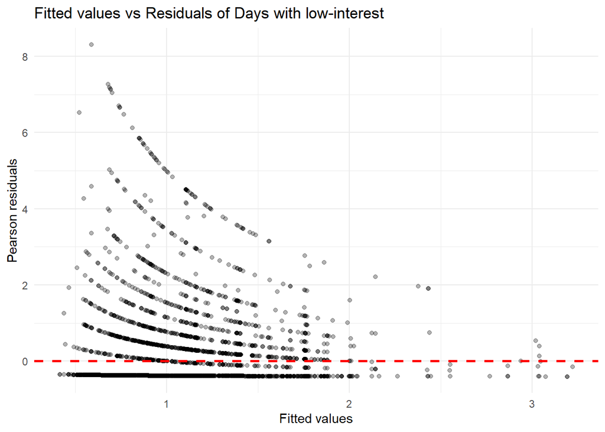

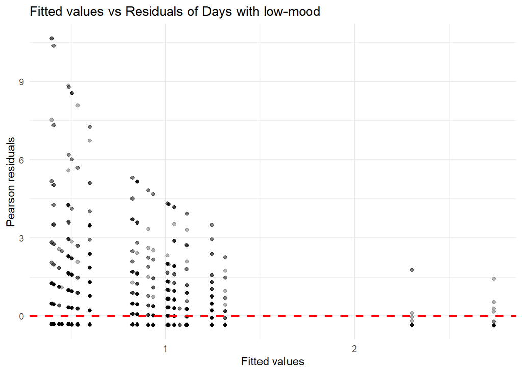

The plots confirm a bit of heteroscedasticity because there is a pattern and points are not randomly spread: residual variability decreases as the fitted values increase. They highlight some cases with very large residuals (greater than 8/9) to consider carefully. But in a count model it’s quite normal to have wider residuals where the fitted values are lower or higher because variance increases with the mean.

# 6 Conclusions

In conclusion, this analysis has highlighted highly significant insights: the models reveal robust and statistical significant results and clear practical interpretations. These findings underscore the crucial importance of prevention in the medical field: promoting an active lifestyle, a balanced diet, and ongoing monitoring of cardiovascular and chronic risk factors is not only a strategy to reduce disease onset but also a direct investment in people’s psycho-physical quality of life.  
Only through targeted preventive interventions and a multidimensional approach to health care we truly enhance collective well-being, reduce disease morbidity rate, and strengthen both individual and social resilience.  
**© 2025 Giacomo Angeletti, Edoardo Crapanzano, Vlad Adrian Dumitru, Francesco Zago. All rights reserved.**